# Summary of cell type ontologies in reference files

Ally Hawkins

2024-12-18

This notebook aims to identify a set of consensus labels between cell types in the PanglaoDB and Blueprint Encode references.

- First I look at the entire cell type ontology and summarize the total ancestors and descendants.
- Then we find all possible combinations of cell type labels between PanglaoDB and Blueprint Encode and find the latest common ancestor (LCA) for all combinations.
- The total descendants for each LCA is used to define a cutoff for consensus terms we may want to use.
- I also explored the pairs for some terms in depth to look at borderline LCA terms.
- Finally, I calculated the similarity index for all pairs.

## Setup

```r
suppressPackageStartupMessages({
  # load required packages
  library(ggplot2)
})

# Set default ggplot theme
theme_set(
  theme_bw()
)
```

```r
# The base path for the OpenScPCA repository, found by its (hidden) .git directory
repository_base <- rprojroot::find_root(rprojroot::is_git_root)

# The path to this module
ref_dir <- file.path(repository_base, "analyses", "cell-type-consensus", "references")

# path to ref file for panglao
panglao_file <- file.path(ref_dir, "panglao-cell-type-ontologies.tsv")
```

```r
# grab obo file
cl_ont <- ontologyIndex::get_ontology("http://purl.obolibrary.org/obo/cl-basic.obo")

# read in panglao file
panglao_df <- readr::read_tsv(panglao_file) |>
  # rename columns to have panglao in them for easy joining later
  dplyr::select(
    panglao_ontology = "ontology_id",
    panglao_annotation = "human_readable_value"
  )
# grab singler ref from celldex
blueprint_ref <- celldex::BlueprintEncodeData()
# get ontologies and human readable name into data frame
blueprint_df <- data.frame(
  blueprint_ontology = blueprint_ref$label.ont,
  blueprint_annotation_main = blueprint_ref$label.main,
  blueprint_annotation_fine = blueprint_ref$label.fine
) |>
  unique()
```

## Full cell ontology

Below I will calculate the total number of ancestors and the total number of descendants for each term in the full cell type ontology and then show the distributions for those statistics. This will give us an idea of the range of values we expect to see when looking at the PanglaoDB and Blueprint Encode references.

```r
# turn cl_ont into data frame with one row per term
cl_df <- data.frame(
  cl_ontology = cl_ont$id,
  cl_annotation = cl_ont$name
) |>
  dplyr::rowwise() |>
  dplyr::mutate(
    # list all ancestors and descendants calculate total
    ancestors = list(ontologyIndex::get_ancestors(cl_ont, cl_ontology)),
    total_ancestors = length(ancestors),
    descendants = list(ontologyIndex::get_descendants(cl_ont, cl_ontology, exclude_roots = TRUE)),
    total_descendants = length(descendants)
  )
```

The vertical lines in the below plot indicate the value for cell types of varying granularity.

```r
celltypes_of_interest <- c("eukaryotic cell", "lymphocyte", "leukocyte", "hematopoietic cell", "T cell", "endothelial cell", "smooth muscle cell", "memory T cell")
line_df <- cl_df |>
  dplyr::filter(cl_annotation %in% celltypes_of_interest) |>
  dplyr::select(cl_annotation, total_descendants, total_ancestors) |>
  unique()

# group any labels that have the same number of ancestors
ancestor_labels_df <- line_df |>
  dplyr::group_by(total_ancestors) |>
  dplyr::summarise(cl_annotation = paste(cl_annotation, collapse = ","))
```

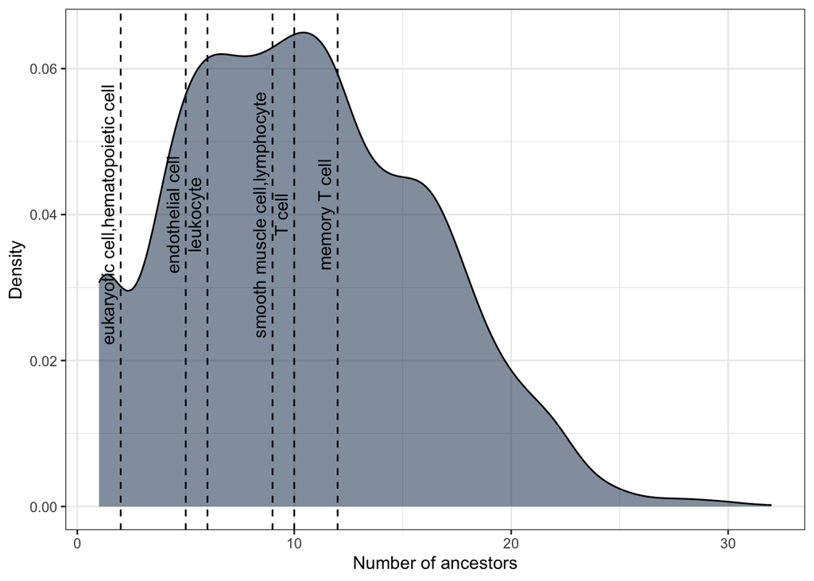

```r
# make density plots showing distribution of ancestors and descendants
ggplot(cl_df, aes(x = total_ancestors)) +
  geom_density(fill = "#00274C", alpha = 0.5) +
  geom_vline(data = ancestor_labels_df,
             mapping = aes(xintercept = total_ancestors),
             lty = 2) +
  geom_text(
    data = ancestor_labels_df,
    mapping = aes(x = total_ancestors, y = 0.04, label = cl_annotation),
    angle = 90,
    vjust = -0.5
  ) +
  labs(
    x = "Number of ancestors",
    y = "Density"
  )
```

Generally it looks like as the cell types get more specific we see a greater number of ancestors. However, the range of values is small and we see some cell types have the same value and probably not the same level of granularity.

Below we will look at total number of descendants.

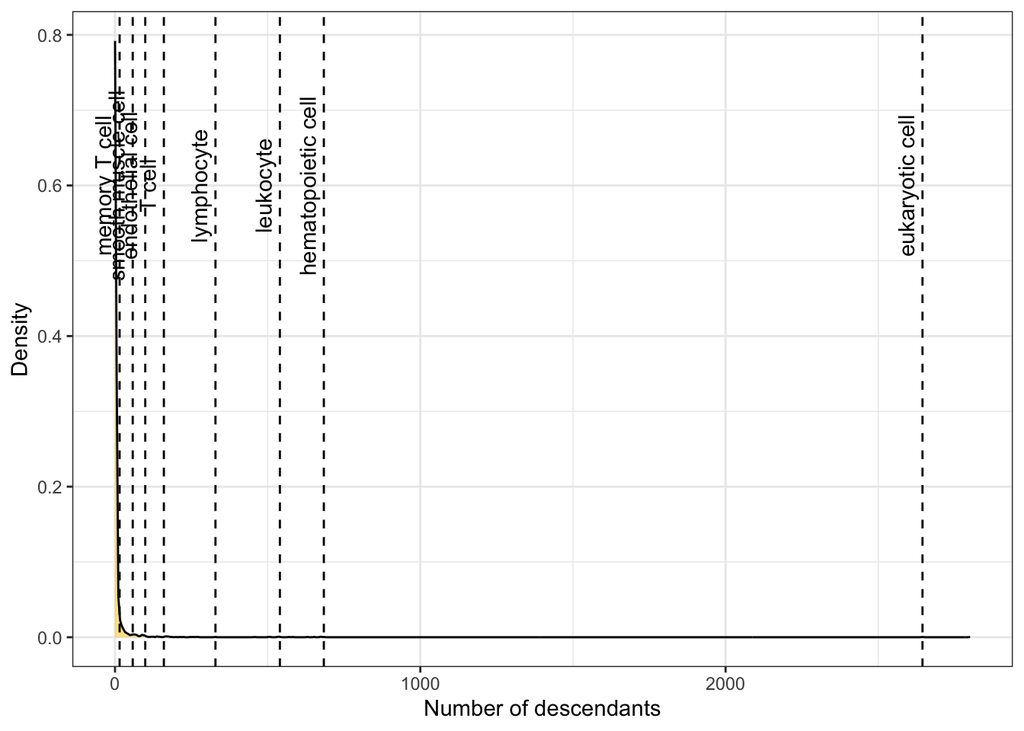

```r
ggplot(cl_df, aes(x = total_descendants)) +
  geom_density(fill = "#FFCB05", alpha = 0.5) +
  geom_vline(data = line_df,
             mapping = aes(xintercept = total_descendants),
             lty = 2) +
  geom_text(
    data = line_df,
    mapping = aes(x = total_descendants, y = 0.6, label = cl_annotation),
    angle = 90,
    vjust = -0.5
  ) +
  labs(
    x = "Number of descendants",
    y = "Density"
  )
```

It looks like most cell types have very few descendants, so let’s zoom into the area below 500 to get a better look.

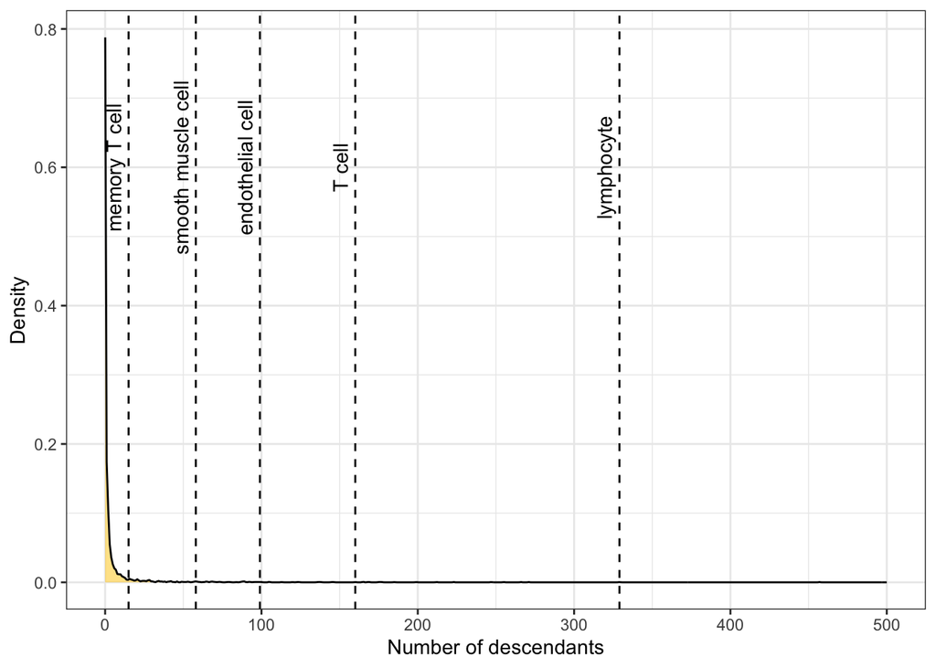

```r
ggplot(cl_df, aes(x = total_descendants)) +
  geom_density(fill = "#FFCB05", alpha = 0.5) +
  geom_vline(data = line_df,
             mapping = aes(xintercept = total_descendants),
             lty = 2) +
  geom_text(
    data = line_df,
    mapping = aes(x = total_descendants, y = 0.6, label = cl_annotation),
    angle = 90,
    vjust = -0.5
  ) +
  labs(
    x = "Number of descendants",
    y = "Density"
  ) +
  xlim(c(0,500))
```

Here we see a much larger range of values and that cell types become more general as the number of descendants goes up. However, this distribution alone is probably not helpful in determining a cutoff. The next section we will look at this distribution specifically for cell types present in our references, PanglaoDB and Blueprint encode.

## Latest common ancestor (LCA) between PanglaoDB and Blueprint encode

This section will look at identifying the latest common ancestor (LCA) between all possible combinations of terms from PanglaoDB (used for assigning cell types with `CellAssign`) and the `BlueprintEncodeData` reference from `celldex` (used for assigning cell types with `SingleR`). The LCA refers to the latest term in the cell ontology hierarchy that is common between two terms. I will use the [`ontoProc::findCommonAncestors()` function](https://rdrr.io/bioc/ontoProc/man/findCommonAncestors.html) to get the LCA for each combination.

Note that it is possible to have more than one LCA for a set of terms. To start, I will keep all LCA terms found.

For each LCA, I will again look at the total number of ancestors and descendants and see if I can identify an appropriate cutoff. Ultimately, I would like to see if we can use that cutoff to decide if we should keep the LCA term as the consensus label or use “Unknown”.

```r
# first set up the graph from cl ont
parent_terms <- cl_ont$parents
cl_graph <- igraph::make_graph(rbind(unlist(parent_terms), rep(names(parent_terms), lengths(parent_terms))))
```

```r
# get a data frame with all combinations of panglao and blueprint terms
# one row for each combination
all_ref_df <- expand.grid(panglao_df$panglao_ontology,
                          blueprint_df$blueprint_ontology) |>
  dplyr::rename(
    panglao_ontology = "Var1",
    blueprint_ontology = "Var2"
  ) |>
  # add in the human readable values for each ontology term
  dplyr::left_join(blueprint_df, by = "blueprint_ontology") |>
  dplyr::left_join(panglao_df, by = "panglao_ontology") |>
  tidyr::drop_na() |>
  dplyr::rowwise() |>
  dplyr::mutate(
    # least common shared ancestor
    lca = list(rownames(ontoProc::findCommonAncestors(blueprint_ontology, panglao_ontology, g = cl_graph)))
  )
lca_df <- all_ref_df |>
  dplyr::mutate(
    total_lca = length(lca), # max is three terms
    lca = paste0(lca, collapse = ",") # make it easier to split the df
  ) |>
  # split each lca term into its own column
  tidyr::separate(lca, into = c("lca_1", "lca_2", "lca_3"), sep = ",") |>
  tidyr::pivot_longer(
    cols = dplyr::starts_with("lca"),
    names_to = "lca_number",
    values_to = "lca"
  ) |>
  tidyr::drop_na() |>
  dplyr::select(-lca_number) |>
  # account for any cases where the ontology IDs are exact matches
  # r complains about doing this earlier since the lca column holds lists until now
  dplyr::mutate(lca = dplyr::if_else(blueprint_ontology == panglao_ontology, blueprint_ontology, lca)) |>
  # join in information for each of the lca terms including name, number of ancestors and descendants
  dplyr::left_join(cl_df, by = c("lca" = "cl_ontology"))
```

### Distribution of ancestors and descendants

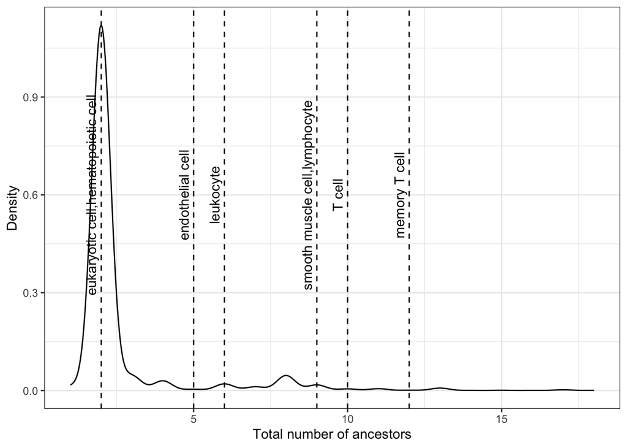

```r
ggplot(lca_df, aes(x = total_ancestors)) +
  geom_density() +
  geom_vline(data = ancestor_labels_df,
             mapping = aes(xintercept = total_ancestors),
             lty = 2) +
  geom_text(
    data = ancestor_labels_df,
    mapping = aes(x = total_ancestors, y = 0.6, label = cl_annotation),
    angle = 90,
    vjust = -0.5
  ) +
  labs(
    x = "Total number of ancestors",
    y = "Density"
  )
```

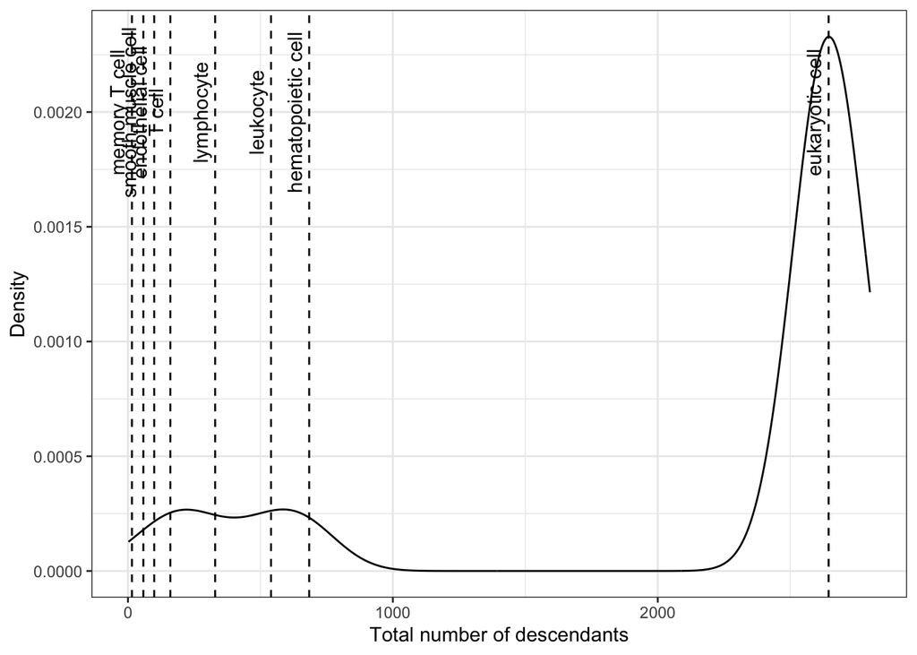

```r
ggplot(lca_df, aes(x = total_descendants)) +
  geom_density() +
  geom_vline(data = line_df,
             mapping = aes(xintercept = total_descendants),
             lty = 2) +
  geom_text(
    data = line_df,
    mapping = aes(x = total_descendants, y = 0.002, label = cl_annotation),
    angle = 90,
    vjust = -0.5
  ) +
  labs(
    x = "Total number of descendants",
    y = "Density"
  )
```

Let’s zoom into the area below 1000, since we already know we would want to exlude anything above that based on this plot.

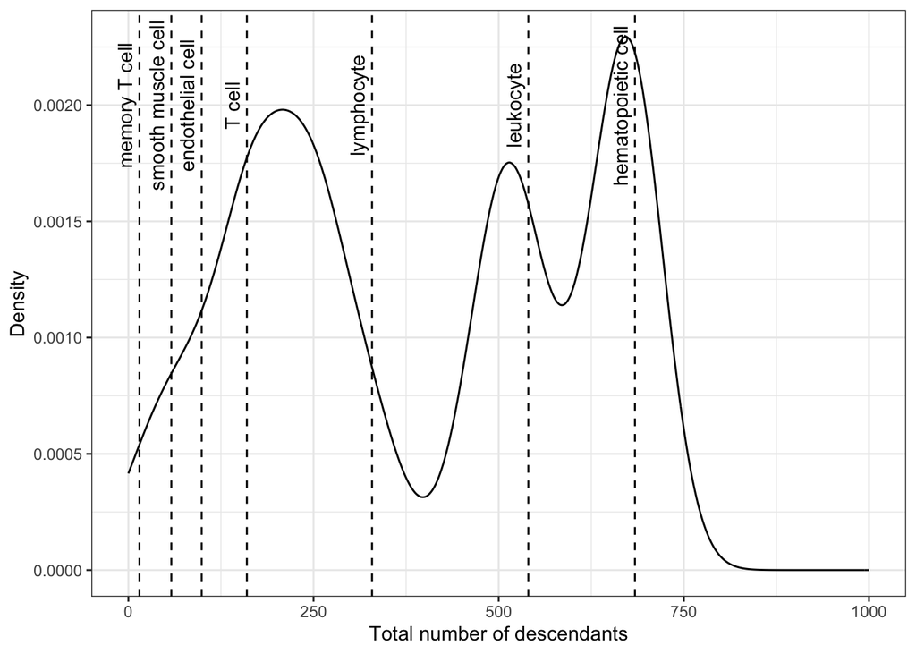

```r
ggplot(lca_df, aes(x = total_descendants)) +
  geom_density() +
  geom_vline(data = line_df,
             mapping = aes(xintercept = total_descendants),
             lty = 2) +
  geom_text(
    data = line_df,
    mapping = aes(x = total_descendants, y = 0.002, label = cl_annotation),
    angle = 90,
    vjust = -0.5
  ) +
  xlim(c(0, 1000)) +
  labs(
    x = "Total number of descendants",
    y = "Density"
  )
```

We can use the vertical lines for cells of interest to help us define a potential cutoff based on the granularity we would like to see in our consensus label. We want to be able to label things like T cell, but we don’t want to label anything as lymphocyte as that’s probably not helpful. I don’t see any obvious cutoffs that may be present in the total number of ancestors, but the number of descendants is likely to be informative. I think it might be a good idea to start by drawing a line at the local maxima between the T cell and lymphocyte lines on the number of descendants graph.

### Defining a cutoff for number of descendants

First we will find the value for the first peak shown in the distribution. This is likely to be a good cutoff for deciding which LCA labels to keep.

```r
peak_idx <- splus2R::peaks(lca_df$total_descendants)
cutoff <- lca_df$total_descendants[peak_idx] |>
  min() # find the smallest peak and use that as the cutoff for number of descendants
```

Below is the list of all consensus cell type labels that we will be keeping if we were to just use this cutoff.

```r
celltypes_to_keep <- lca_df |>
  dplyr::filter(total_descendants <= cutoff) |>
  dplyr::pull(cl_annotation) |>
  unique()

celltypes_to_keep
```

```
##  [1] "myeloid leukocyte"                   "granulocyte"                         "neutrophil"
##  [4] "blood cell"                          "mononuclear phagocyte"               "progenitor cell"
##  [7] "monocyte"                            "hematopoietic precursor cell"        "T cell"
## [10] "CD4-positive, alpha-beta T cell"     "mature alpha-beta T cell"            "mature T cell"
## [13] "regulatory T cell"                   "memory T cell"                       "natural killer cell"
## [16] "innate lymphoid cell"                "B cell"                              "lymphocyte of B lineage"
## [19] "mature B cell"                       "naive B cell"                        "memory B cell"
## [22] "somatic stem cell"                   "stem cell"                           "hematopoietic stem cell"
## [25] "bone cell"                           "macrophage"                          "erythroid lineage cell"
## [28] "megakaryocyte"                       "endothelial cell"                    "lining cell"
## [31] "dendritic cell"                      "eosinophil"                          "plasma cell"
## [34] "chondrocyte"                         "stromal cell"                        "extracellular matrix secreting cell"
## [37] "fibroblast"                          "smooth muscle cell"                  "muscle cell"
## [40] "melanocyte"                          "cell of skeletal muscle"             "ecto-epithelial cell"
## [43] "keratinocyte"                        "squamous epithelial cell"            "epidermal cell"
## [46] "blood vessel endothelial cell"       "microvascular endothelial cell"      "adipocyte"
## [49] "pericyte"                            "perivascular cell"                   "supporting cell"
## [52] "astrocyte"                           "glial cell"                          "macroglial cell"
## [55] "neuron associated cell"              "mesangial cell"
```

We can also look at all the cell types we are keeping and the total number of descendants to see if there are any that may be we don’t want to include because the term is too braod.

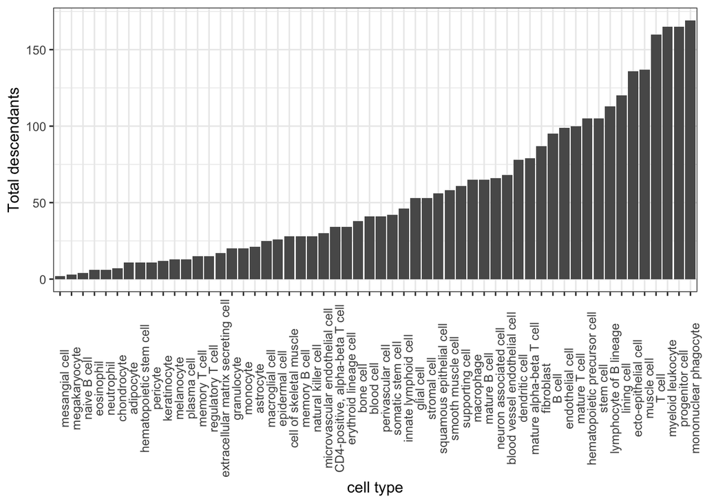

```r
# pull out the cell types and total descendants for cell types to keep
plot_celltype_df <- lca_df |>
  dplyr::filter(cl_annotation %in% celltypes_to_keep) |>
  dplyr::select(cl_annotation, total_descendants) |>
  unique()

# bar chart showing total number of descendants for each cell type
ggplot(plot_celltype_df, aes(x = reorder(cl_annotation, total_descendants), y = total_descendants)) +
  geom_bar(stat = "identity") +
  theme(
    axis.text.x = element_text(angle = 90)
  ) +
  labs(
    x = "cell type",
    y = "Total descendants"
  )
```

There are a few terms that I think might be more broad than we want like `blood cell`, `bone cell`,

```
supporting
cell
```

, and `lining cell`. I’m on the fence about keeping `myeloid leukocyte` and `progenitor cell`. I think if we wanted to remove those terms we could move our cutoff to be the same number of descendants as `T cell`, since we do want to keep that.

One could also argue to remove `stromal cell` or `extracellular matrix secreting cell`.

Below are tables that look specifically at the combinations of cell type annotations that resulted in some of the terms that I might consider removing.

#### Blood cell

```r
print_df <- lca_df |>
  dplyr::select(blueprint_ontology, blueprint_annotation_main, blueprint_annotation_fine, panglao_ontology, panglao_annotation, total_lca, lca, cl_annotation)

# blood cell
print_df |>
  dplyr::filter(cl_annotation == "blood cell")
```

| blueprint_ontology | blueprint_annotation_main | blueprint_annotation_fine | panglao_ontology | panglao_annotation | total_lca | lca | cl_annotation |
| --- | --- | --- | --- | --- | --- | --- | --- |
| CL:0000775 | Neutrophils | Neutrophils | CL:0000233 | platelet | 2 | CL:0000081 | blood cell |
| CL:0000232 | Erythrocytes | Erythrocytes | CL:0000767 | basophil | 2 | CL:0000081 | blood cell |
| CL:0000232 | Erythrocytes | Erythrocytes | CL:0000771 | eosinophil | 2 | CL:0000081 | blood cell |
| CL:0000232 | Erythrocytes | Erythrocytes | CL:0000775 | neutrophil | 2 | CL:0000081 | blood cell |
| CL:0000232 | Erythrocytes | Erythrocytes | CL:0000233 | platelet | 2 | CL:0000081 | blood cell |
| CL:0000771 | Eosinophils | Eosinophils | CL:0000233 | platelet | 2 | CL:0000081 | blood cell |

I think I’m in favor of not having a “blood cell” label, since I’m not sure that it’s helpful. Also, if two different methods label something a platelet and a neutrophil, then perhaps that label is inaccurate and it’s really a tumor cell.

#### Bone cell

```r
# bone cell
print_df |>
  dplyr::filter(cl_annotation == "bone cell")
```

| blueprint_ontology | blueprint_annotation_main | blueprint_annotation_fine | panglao_ontology | panglao_annotation | total_lca | lca | cl_annotation |
| --- | --- | --- | --- | --- | --- | --- | --- |
| CL:0000557 | HSC | GMP | CL:0000092 | osteoclast | 2 | CL:0001035 | bone cell |
| CL:0000557 | HSC | GMP | CL:0000137 | osteocyte | 1 | CL:0001035 | bone cell |

I think I would also remove bone cell, since hematopoietic stem cells and osteoclasts seem pretty different to me.

#### Myeloid leukocyte

```r
# myeloid leukocyte cell
print_df |>
  dplyr::filter(cl_annotation == "myeloid leukocyte")
```

| blueprint_ontology | blueprint_annotation_main | blueprint_annotation_fine | panglao_ontology | panglao_annotation | total_lca | lca | cl_annotation |
| --- | --- | --- | --- | --- | --- | --- | --- |
| CL:0000775 | Neutrophils | Neutrophils | CL:0000583 | alveolar macrophage | 1 | CL:0000766 | myeloid leukocyte |
| CL:0000775 | Neutrophils | Neutrophils | CL:0000235 | macrophage | 1 | CL:0000766 | myeloid leukocyte |
| CL:0000775 | Neutrophils | Neutrophils | CL:0000097 | mast cell | 1 | CL:0000766 | myeloid leukocyte |
| CL:0000775 | Neutrophils | Neutrophils | CL:0000576 | monocyte | 1 | CL:0000766 | myeloid leukocyte |
| CL:0000775 | Neutrophils | Neutrophils | CL:0000576 | monocyte | 1 | CL:0000766 | myeloid leukocyte |
| CL:0000775 | Neutrophils | Neutrophils | CL:0000092 | osteoclast | 1 | CL:0000766 | myeloid leukocyte |
| CL:0000775 | Neutrophils | Neutrophils | CL:0000091 | Kupffer cell | 1 | CL:0000766 | myeloid leukocyte |
| CL:0000775 | Neutrophils | Neutrophils | CL:0000453 | Langerhans cell | 1 | CL:0000766 | myeloid leukocyte |
| CL:0000775 | Neutrophils | Neutrophils | CL:0000129 | microglial cell | 1 | CL:0000766 | myeloid leukocyte |
| CL:0000775 | Neutrophils | Neutrophils | CL:0000889 | myeloid suppressor cell | 1 | CL:0000766 | myeloid leukocyte |
| CL:0000775 | Neutrophils | Neutrophils | CL:0000576 | monocyte | 1 | CL:0000766 | myeloid leukocyte |
| CL:0000775 | Neutrophils | Neutrophils | CL:0000576 | monocyte | 1 | CL:0000766 | myeloid leukocyte |
| CL:0000775 | Neutrophils | Neutrophils | CL:0000874 | splenic red pulp macrophage | 1 | CL:0000766 | myeloid leukocyte |
| CL:0000576 | Monocytes | Monocytes | CL:0000583 | alveolar macrophage | 2 | CL:0000766 | myeloid leukocyte |
| CL:0000576 | Monocytes | Monocytes | CL:0000767 | basophil | 1 | CL:0000766 | myeloid leukocyte |
| CL:0000576 | Monocytes | Monocytes | CL:0000771 | eosinophil | 1 | CL:0000766 | myeloid leukocyte |
| CL:0000576 | Monocytes | Monocytes | CL:0000235 | macrophage | 2 | CL:0000766 | myeloid leukocyte |
| CL:0000576 | Monocytes | Monocytes | CL:0000097 | mast cell | 1 | CL:0000766 | myeloid leukocyte |
| CL:0000576 | Monocytes | Monocytes | CL:0000775 | neutrophil | 1 | CL:0000766 | myeloid leukocyte |
| CL:0000576 | Monocytes | Monocytes | CL:0000092 | osteoclast | 2 | CL:0000766 | myeloid leukocyte |
| CL:0000576 | Monocytes | Monocytes | CL:0000091 | Kupffer cell | 2 | CL:0000766 | myeloid leukocyte |
| CL:0000576 | Monocytes | Monocytes | CL:0000453 | Langerhans cell | 2 | CL:0000766 | myeloid leukocyte |
| CL:0000576 | Monocytes | Monocytes | CL:0000129 | microglial cell | 2 | CL:0000766 | myeloid leukocyte |
| CL:0000576 | Monocytes | Monocytes | CL:0000889 | myeloid suppressor cell | 1 | CL:0000766 | myeloid leukocyte |
| CL:0000576 | Monocytes | Monocytes | CL:0000874 | splenic red pulp macrophage | 2 | CL:0000766 | myeloid leukocyte |
| CL:0000235 | Macrophages | Macrophages | CL:0000767 | basophil | 1 | CL:0000766 | myeloid leukocyte |
| CL:0000235 | Macrophages | Macrophages | CL:0000771 | eosinophil | 1 | CL:0000766 | myeloid leukocyte |
| CL:0000235 | Macrophages | Macrophages | CL:0000097 | mast cell | 1 | CL:0000766 | myeloid leukocyte |
| CL:0000235 | Macrophages | Macrophages | CL:0000576 | monocyte | 2 | CL:0000766 | myeloid leukocyte |
| CL:0000235 | Macrophages | Macrophages | CL:0000576 | monocyte | 2 | CL:0000766 | myeloid leukocyte |
| CL:0000235 | Macrophages | Macrophages | CL:0000775 | neutrophil | 1 | CL:0000766 | myeloid leukocyte |
| CL:0000235 | Macrophages | Macrophages | CL:0000092 | osteoclast | 2 | CL:0000766 | myeloid leukocyte |
| CL:0000235 | Macrophages | Macrophages | CL:0000453 | Langerhans cell | 3 | CL:0000766 | myeloid leukocyte |
| CL:0000235 | Macrophages | Macrophages | CL:0000889 | myeloid suppressor cell | 1 | CL:0000766 | myeloid leukocyte |
| CL:0000235 | Macrophages | Macrophages | CL:0000576 | monocyte | 2 | CL:0000766 | myeloid leukocyte |
| CL:0000235 | Macrophages | Macrophages | CL:0000576 | monocyte | 2 | CL:0000766 | myeloid leukocyte |
| CL:0000863 | Macrophages | Macrophages M1 | CL:0000767 | basophil | 1 | CL:0000766 | myeloid leukocyte |
| CL:0000863 | Macrophages | Macrophages M1 | CL:0000771 | eosinophil | 1 | CL:0000766 | myeloid leukocyte |
| CL:0000863 | Macrophages | Macrophages M1 | CL:0000097 | mast cell | 1 | CL:0000766 | myeloid leukocyte |
| CL:0000863 | Macrophages | Macrophages M1 | CL:0000576 | monocyte | 2 | CL:0000766 | myeloid leukocyte |
| CL:0000863 | Macrophages | Macrophages M1 | CL:0000576 | monocyte | 2 | CL:0000766 | myeloid leukocyte |
| CL:0000863 | Macrophages | Macrophages M1 | CL:0000775 | neutrophil | 1 | CL:0000766 | myeloid leukocyte |
| CL:0000863 | Macrophages | Macrophages M1 | CL:0000092 | osteoclast | 2 | CL:0000766 | myeloid leukocyte |
| CL:0000863 | Macrophages | Macrophages M1 | CL:0000453 | Langerhans cell | 3 | CL:0000766 | myeloid leukocyte |
| CL:0000863 | Macrophages | Macrophages M1 | CL:0000889 | myeloid suppressor cell | 1 | CL:0000766 | myeloid leukocyte |
| CL:0000863 | Macrophages | Macrophages M1 | CL:0000576 | monocyte | 2 | CL:0000766 | myeloid leukocyte |
| CL:0000863 | Macrophages | Macrophages M1 | CL:0000576 | monocyte | 2 | CL:0000766 | myeloid leukocyte |
| CL:0000890 | Macrophages | Macrophages M2 | CL:0000767 | basophil | 1 | CL:0000766 | myeloid leukocyte |
| CL:0000890 | Macrophages | Macrophages M2 | CL:0000771 | eosinophil | 1 | CL:0000766 | myeloid leukocyte |
| CL:0000890 | Macrophages | Macrophages M2 | CL:0000097 | mast cell | 1 | CL:0000766 | myeloid leukocyte |
| CL:0000890 | Macrophages | Macrophages M2 | CL:0000576 | monocyte | 2 | CL:0000766 | myeloid leukocyte |
| CL:0000890 | Macrophages | Macrophages M2 | CL:0000576 | monocyte | 2 | CL:0000766 | myeloid leukocyte |
| CL:0000890 | Macrophages | Macrophages M2 | CL:0000775 | neutrophil | 1 | CL:0000766 | myeloid leukocyte |
| CL:0000890 | Macrophages | Macrophages M2 | CL:0000092 | osteoclast | 2 | CL:0000766 | myeloid leukocyte |
| CL:0000890 | Macrophages | Macrophages M2 | CL:0000453 | Langerhans cell | 3 | CL:0000766 | myeloid leukocyte |
| CL:0000890 | Macrophages | Macrophages M2 | CL:0000889 | myeloid suppressor cell | 1 | CL:0000766 | myeloid leukocyte |
| CL:0000890 | Macrophages | Macrophages M2 | CL:0000576 | monocyte | 2 | CL:0000766 | myeloid leukocyte |
| CL:0000890 | Macrophages | Macrophages M2 | CL:0000576 | monocyte | 2 | CL:0000766 | myeloid leukocyte |
| CL:0000771 | Eosinophils | Eosinophils | CL:0000583 | alveolar macrophage | 1 | CL:0000766 | myeloid leukocyte |
| CL:0000771 | Eosinophils | Eosinophils | CL:0000235 | macrophage | 1 | CL:0000766 | myeloid leukocyte |
| CL:0000771 | Eosinophils | Eosinophils | CL:0000097 | mast cell | 1 | CL:0000766 | myeloid leukocyte |
| CL:0000771 | Eosinophils | Eosinophils | CL:0000576 | monocyte | 1 | CL:0000766 | myeloid leukocyte |
| CL:0000771 | Eosinophils | Eosinophils | CL:0000576 | monocyte | 1 | CL:0000766 | myeloid leukocyte |
| CL:0000771 | Eosinophils | Eosinophils | CL:0000092 | osteoclast | 1 | CL:0000766 | myeloid leukocyte |
| CL:0000771 | Eosinophils | Eosinophils | CL:0000091 | Kupffer cell | 1 | CL:0000766 | myeloid leukocyte |
| CL:0000771 | Eosinophils | Eosinophils | CL:0000453 | Langerhans cell | 1 | CL:0000766 | myeloid leukocyte |
| CL:0000771 | Eosinophils | Eosinophils | CL:0000129 | microglial cell | 1 | CL:0000766 | myeloid leukocyte |
| CL:0000771 | Eosinophils | Eosinophils | CL:0000889 | myeloid suppressor cell | 1 | CL:0000766 | myeloid leukocyte |
| CL:0000771 | Eosinophils | Eosinophils | CL:0000576 | monocyte | 1 | CL:0000766 | myeloid leukocyte |
| CL:0000771 | Eosinophils | Eosinophils | CL:0000576 | monocyte | 1 | CL:0000766 | myeloid leukocyte |
| CL:0000771 | Eosinophils | Eosinophils | CL:0000874 | splenic red pulp macrophage | 1 | CL:0000766 | myeloid leukocyte |

I’m torn on this one, because I do think it’s helpful to know if something is of the myeloid lineage, but if we aren’t keeping lymphocyte then I would argue we shouldn’t keep myeloid leukocyte. Noting that after discussion we have decided to keep this one since T and B cells are much easier to differentiate based on gene expression alone than cells that are part of the myeloid lineage.

#### Progenitor cell

```r
# progenitor cell
print_df |>
  dplyr::filter(cl_annotation == "progenitor cell") |>
  head(n=15) # there's a lot of these so let's only print out some
```

| blueprint_ontology | blueprint_annotation_main | blueprint_annotation_fine | panglao_ontology | panglao_annotation | total_lca | lca | cl_annotation |
| --- | --- | --- | --- | --- | --- | --- | --- |
| CL:0000576 | Monocytes | Monocytes | CL:0000765 | erythroblast | 2 | CL:0011026 | progenitor cell |
| CL:0000576 | Monocytes | Monocytes | CL:0000037 | hematopoietic stem cell | 2 | CL:0011026 | progenitor cell |
| CL:0000576 | Monocytes | Monocytes | CL:0000062 | osteoblast | 1 | CL:0011026 | progenitor cell |
| CL:0000576 | Monocytes | Monocytes | CL:0000158 | club cell | 1 | CL:0011026 | progenitor cell |
| CL:0000576 | Monocytes | Monocytes | CL:0000038 | erythroid progenitor cell | 2 | CL:0011026 | progenitor cell |
| CL:0000576 | Monocytes | Monocytes | CL:4042021 | neuronal-restricted precursor | 1 | CL:0011026 | progenitor cell |
| CL:0000576 | Monocytes | Monocytes | CL:0002453 | oligodendrocyte precursor cell | 1 | CL:0011026 | progenitor cell |
| CL:0000576 | Monocytes | Monocytes | CL:0002351 | progenitor cell of endocrine pancreas | 1 | CL:0011026 | progenitor cell |
| CL:0000050 | HSC | MEP | CL:0000765 | erythroblast | 2 | CL:0011026 | progenitor cell |
| CL:0000050 | HSC | MEP | CL:0000037 | hematopoietic stem cell | 2 | CL:0011026 | progenitor cell |
| CL:0000050 | HSC | MEP | CL:0000576 | monocyte | 2 | CL:0011026 | progenitor cell |
| CL:0000050 | HSC | MEP | CL:0000576 | monocyte | 2 | CL:0011026 | progenitor cell |
| CL:0000050 | HSC | MEP | CL:0000062 | osteoblast | 1 | CL:0011026 | progenitor cell |
| CL:0000050 | HSC | MEP | CL:0000158 | club cell | 1 | CL:0011026 | progenitor cell |
| CL:0000050 | HSC | MEP | CL:0000038 | erythroid progenitor cell | 3 | CL:0011026 | progenitor cell |

Same with `progenitor cell`, I do think it could be helpful to know that something may be a progenitor cell, but when you have a cell with the label for HSC and the label for cells like monocytes or osteoblasts, then maybe we are talking about a tumor cell instead. After discussion, we are going to remove progenitor cells.

Along those same lines, I think the below terms,

```
lining
cell
```

and `supporting cell`, are too broad even though they have few descendants.

#### Lining cell

```r
# lining cell
print_df |>
  dplyr::filter(cl_annotation == "lining cell")
```

| blueprint_ontology | blueprint_annotation_main | blueprint_annotation_fine | panglao_ontology | panglao_annotation | total_lca | lca | cl_annotation |
| --- | --- | --- | --- | --- | --- | --- | --- |
| CL:0000115 | Endothelial cells | Endothelial cells | CL:0000077 | mesothelial cell | 2 | CL:0000213 | lining cell |
| CL:0000115 | Endothelial cells | Endothelial cells | CL:0002481 | peritubular myoid cell | 2 | CL:0000213 | lining cell |
| CL:0000115 | Endothelial cells | Endothelial cells | CL:0000216 | Sertoli cell | 2 | CL:0000213 | lining cell |
| CL:2000008 | Endothelial cells | mv Endothelial cells | CL:0000077 | mesothelial cell | 2 | CL:0000213 | lining cell |
| CL:2000008 | Endothelial cells | mv Endothelial cells | CL:0002481 | peritubular myoid cell | 2 | CL:0000213 | lining cell |
| CL:2000008 | Endothelial cells | mv Endothelial cells | CL:0000216 | Sertoli cell | 2 | CL:0000213 | lining cell |

#### Supporting cell

```r
# supporting cell
print_df |>
  dplyr::filter(cl_annotation == "supporting cell")
```

| blueprint_ontology | blueprint_annotation_main | blueprint_annotation_fine | panglao_ontology | panglao_annotation | total_lca | lca | cl_annotation |
| --- | --- | --- | --- | --- | --- | --- | --- |
| CL:0000669 | Pericytes | Pericytes | CL:0000216 | Sertoli cell | 2 | CL:0000630 | supporting cell |
| CL:0000650 | Mesangial cells | Mesangial cells | CL:0000216 | Sertoli cell | 2 | CL:0000630 | supporting cell |

### Discarded cell types

We can also look at what cell type labels we are excluding when using this cut off to see if there are any terms we might actually want to keep instead.

```r
lca_df |>
  dplyr::filter(total_descendants > cutoff) |>
  dplyr::pull(cl_annotation) |>
  unique()
```

```
##  [1] "leukocyte"                            "eukaryotic cell"                      "myeloid cell"
##  [4] "cell"                                 "hematopoietic cell"                   "mononuclear cell"
##  [7] "stuff accumulating cell"              "precursor cell"                       "phagocyte (sensu Vertebrata)"
## [10] "defensive cell"                       "lymphocyte"                           "professional antigen presenting cell"
## [13] "secretory cell"                       "connective tissue cell"               "electrically responsive cell"
## [16] "contractile cell"                     "epithelial cell"                      "neuron"
## [19] "neural cell"
```

The only terms in this list that I would be concerned about losing are “neuron” and epithelial cells. Let’s look at those combinations.

#### Neuron

```r
# neuron
print_df |>
  dplyr::filter(cl_annotation == "neuron")
```

| blueprint_ontology | blueprint_annotation_main | blueprint_annotation_fine | panglao_ontology | panglao_annotation | total_lca | lca | cl_annotation |
| --- | --- | --- | --- | --- | --- | --- | --- |
| CL:0000540 | Neurons | Neurons | CL:0000109 | adrenergic neuron | 1 | CL:0000540 | neuron |
| CL:0000540 | Neurons | Neurons | CL:0000108 | cholinergic neuron | 1 | CL:0000540 | neuron |
| CL:0000540 | Neurons | Neurons | CL:0000166 | chromaffin cell | 1 | CL:0000540 | neuron |
| CL:0000540 | Neurons | Neurons | CL:0000700 | dopaminergic neuron | 1 | CL:0000540 | neuron |
| CL:0000540 | Neurons | Neurons | CL:0007011 | enteric neuron | 1 | CL:0000540 | neuron |
| CL:0000540 | Neurons | Neurons | CL:1001509 | glycinergic neuron | 1 | CL:0000540 | neuron |
| CL:0000540 | Neurons | Neurons | CL:0000099 | interneuron | 1 | CL:0000540 | neuron |
| CL:0000540 | Neurons | Neurons | CL:0000100 | motor neuron | 1 | CL:0000540 | neuron |
| CL:0000540 | Neurons | Neurons | CL:0000165 | neuroendocrine cell | 1 | CL:0000540 | neuron |
| CL:0000540 | Neurons | Neurons | CL:0000540 | neuron | 0 | CL:0000540 | neuron |
| CL:0000540 | Neurons | Neurons | CL:0008025 | noradrenergic neuron | 1 | CL:0000540 | neuron |
| CL:0000540 | Neurons | Neurons | CL:0000210 | photoreceptor cell | 1 | CL:0000540 | neuron |
| CL:0000540 | Neurons | Neurons | CL:0000740 | retinal ganglion cell | 1 | CL:0000540 | neuron |
| CL:0000540 | Neurons | Neurons | CL:0000850 | serotonergic neuron | 1 | CL:0000540 | neuron |
| CL:0000540 | Neurons | Neurons | CL:4023169 | trigeminal neuron | 1 | CL:0000540 | neuron |
| CL:0000540 | Neurons | Neurons | CL:0000695 | Cajal-Retzius cell | 1 | CL:0000540 | neuron |
| CL:0000540 | Neurons | Neurons | CL:0000617 | GABAergic neuron | 1 | CL:0000540 | neuron |
| CL:0000540 | Neurons | Neurons | CL:0000679 | glutamatergic neuron | 1 | CL:0000540 | neuron |
| CL:0000540 | Neurons | Neurons | CL:0000121 | Purkinje cell | 1 | CL:0000540 | neuron |
| CL:0000540 | Neurons | Neurons | CL:0000598 | pyramidal neuron | 1 | CL:0000540 | neuron |

It looks like there are a lot of types of neurons in the PanglaoDB reference and only “neuron” as a term in Blueprint. Even though neuron has ~ 500 descendants, I think we should keep these labels.

#### Epithelial cell

```r
# epithelial cell
print_df |>
  dplyr::filter(cl_annotation == "epithelial cell")
```

| blueprint_ontology | blueprint_annotation_main | blueprint_annotation_fine | panglao_ontology | panglao_annotation | total_lca | lca | cl_annotation |
| --- | --- | --- | --- | --- | --- | --- | --- |
| CL:0000066 | Epithelial cells | Epithelial cells | CL:0000622 | acinar cell | 1 | CL:0000066 | epithelial cell |
| CL:0000066 | Epithelial cells | Epithelial cells | CL:1000488 | cholangiocyte | 1 | CL:0000066 | epithelial cell |
| CL:0000066 | Epithelial cells | Epithelial cells | CL:0000166 | chromaffin cell | 1 | CL:0000066 | epithelial cell |
| CL:0000066 | Epithelial cells | Epithelial cells | CL:0000584 | enterocyte | 1 | CL:0000066 | epithelial cell |
| CL:0000066 | Epithelial cells | Epithelial cells | CL:0000164 | enteroendocrine cell | 1 | CL:0000066 | epithelial cell |
| CL:0000066 | Epithelial cells | Epithelial cells | CL:0000065 | ependymal cell | 1 | CL:0000066 | epithelial cell |
| CL:0000066 | Epithelial cells | Epithelial cells | CL:0000066 | epithelial cell | 0 | CL:0000066 | epithelial cell |
| CL:0000066 | Epithelial cells | Epithelial cells | CL:0000160 | goblet cell | 1 | CL:0000066 | epithelial cell |
| CL:0000066 | Epithelial cells | Epithelial cells | CL:0000501 | granulosa cell | 1 | CL:0000066 | epithelial cell |
| CL:0000066 | Epithelial cells | Epithelial cells | CL:0000182 | hepatocyte | 1 | CL:0000066 | epithelial cell |
| CL:0000066 | Epithelial cells | Epithelial cells | CL:0005006 | ionocyte | 1 | CL:0000066 | epithelial cell |
| CL:0000066 | Epithelial cells | Epithelial cells | CL:0000312 | keratinocyte | 1 | CL:0000066 | epithelial cell |
| CL:0000066 | Epithelial cells | Epithelial cells | CL:0000077 | mesothelial cell | 1 | CL:0000066 | epithelial cell |
| CL:0000066 | Epithelial cells | Epithelial cells | CL:0000185 | myoepithelial cell | 1 | CL:0000066 | epithelial cell |
| CL:0000066 | Epithelial cells | Epithelial cells | CL:0000165 | neuroendocrine cell | 1 | CL:0000066 | epithelial cell |
| CL:0000066 | Epithelial cells | Epithelial cells | CL:0002167 | olfactory epithelial cell | 1 | CL:0000066 | epithelial cell |
| CL:0000066 | Epithelial cells | Epithelial cells | CL:0000510 | paneth cell | 1 | CL:0000066 | epithelial cell |
| CL:0000066 | Epithelial cells | Epithelial cells | CL:0000162 | parietal cell | 1 | CL:0000066 | epithelial cell |
| CL:0000066 | Epithelial cells | Epithelial cells | CL:0002481 | peritubular myoid cell | 1 | CL:0000066 | epithelial cell |
| CL:0000066 | Epithelial cells | Epithelial cells | CL:0000652 | pinealocyte | 1 | CL:0000066 | epithelial cell |
| CL:0000066 | Epithelial cells | Epithelial cells | CL:0000653 | podocyte | 1 | CL:0000066 | epithelial cell |
| CL:0000066 | Epithelial cells | Epithelial cells | CL:0000209 | taste receptor cell | 1 | CL:0000066 | epithelial cell |
| CL:0000066 | Epithelial cells | Epithelial cells | CL:0000731 | urothelial cell | 1 | CL:0000066 | epithelial cell |
| CL:0000066 | Epithelial cells | Epithelial cells | CL:0002368 | respiratory epithelial cell | 1 | CL:0000066 | epithelial cell |
| CL:0000066 | Epithelial cells | Epithelial cells | CL:0002370 | respiratory goblet cell | 1 | CL:0000066 | epithelial cell |
| CL:0000066 | Epithelial cells | Epithelial cells | CL:0000171 | pancreatic A cell | 1 | CL:0000066 | epithelial cell |
| CL:0000066 | Epithelial cells | Epithelial cells | CL:0000169 | type B pancreatic cell | 1 | CL:0000066 | epithelial cell |
| CL:0000066 | Epithelial cells | Epithelial cells | CL:0000706 | choroid plexus epithelial cell | 1 | CL:0000066 | epithelial cell |
| CL:0000066 | Epithelial cells | Epithelial cells | CL:0000158 | club cell | 1 | CL:0000066 | epithelial cell |
| CL:0000066 | Epithelial cells | Epithelial cells | CL:0002250 | intestinal crypt stem cell | 1 | CL:0000066 | epithelial cell |

[output cut: 68 more lines]

The PanglaoDB cell types seem to be more specific than the ones present in Blueprint Encode, similar to the observation with neurons. We should keep epithelial cell in the cases where the Blueprint Encode annotation is `Epithelial cells` but not when it is `Keratinocytes`.

### Removing anything with more than 1 LCA

```r
lca_df |>
  dplyr::filter(total_lca > 1) |>
  dplyr::select(cl_annotation, total_descendants) |>
  unique() |>
  dplyr::arrange(total_descendants)
```

| cl_annotation | total_descendants |
| --- | --- |
| bone cell | 38 |
| blood cell | 41 |
| perivascular cell | 41 |
| stromal cell | 53 |
| supporting cell | 61 |
| hematopoietic precursor cell | 105 |
| lining cell | 120 |
| myeloid leukocyte | 165 |
| progenitor cell | 165 |
| mononuclear phagocyte | 169 |
| phagocyte (sensu Vertebrata) | 175 |
| contractile cell | 177 |
| defensive cell | 199 |
| professional antigen presenting cell | 212 |
| connective tissue cell | 223 |
| myeloid cell | 247 |
| stuff accumulating cell | 266 |
| precursor cell | 271 |
| secretory cell | 457 |
| mononuclear cell | 503 |
| leukocyte | 540 |
| electrically responsive cell | 673 |
| hematopoietic cell | 684 |
| eukaryotic cell | 2645 |

It looks like most of these terms are pretty broad and are either much higher than the cutoff or right around the cutoff with a few exceptions. Things like “bone cell” and “supporting cell” have few descendants, but I would still argue these are very broad terms and not useful.

I’m going to filter out any matches that show two LCA terms first and then use the cutoff to define labels we would keep. I’ll also look to see what cell types we lose when we add this extra filtering step to be sure they are ones that we want to lose.

```r
# remove any combinations with more than one lca
filtered_lca_df <- lca_df |>
  dplyr::filter(total_lca < 2)

# get a list of cell types to keep based on cutoff
updated_celltypes <- filtered_lca_df |>
  dplyr::filter(total_descendants <= cutoff) |>
  dplyr::pull(cl_annotation) |>
  unique()

# which cell types are now missing from the list to keep
setdiff(celltypes_to_keep, updated_celltypes)
```

```
## [1] "blood cell"                   "hematopoietic precursor cell" "lining cell"
## [4] "perivascular cell"            "supporting cell"
```

It looks like I am losing a few terms I already said were not specific and then a few other terms, like “hematopoietic precursor cell” and “perivascular cell”. I’ll look at both of those to confirm we would not want them.

#### Hematopoietic precursor cell

```r
print_df |>
  dplyr::filter(cl_annotation == "hematopoietic precursor cell")
```

| blueprint_ontology | blueprint_annotation_main | blueprint_annotation_fine | panglao_ontology | panglao_annotation | total_lca | lca | cl_annotation |
| --- | --- | --- | --- | --- | --- | --- | --- |
| CL:0000050 | HSC | MEP | CL:0000037 | hematopoietic stem cell | 2 | CL:0008001 | hematopoietic precursor cell |
| CL:0000050 | HSC | MEP | CL:0000038 | erythroid progenitor cell | 3 | CL:0008001 | hematopoietic precursor cell |
| CL:0000037 | HSC | HSC | CL:0000038 | erythroid progenitor cell | 2 | CL:0008001 | hematopoietic precursor cell |
| CL:0000837 | HSC | MPP | CL:0000037 | hematopoietic stem cell | 2 | CL:0008001 | hematopoietic precursor cell |
| CL:0000837 | HSC | MPP | CL:0000038 | erythroid progenitor cell | 2 | CL:0008001 | hematopoietic precursor cell |
| CL:0000051 | HSC | CLP | CL:0000037 | hematopoietic stem cell | 2 | CL:0008001 | hematopoietic precursor cell |
| CL:0000051 | HSC | CLP | CL:0000038 | erythroid progenitor cell | 2 | CL:0008001 | hematopoietic precursor cell |
| CL:0000557 | HSC | GMP | CL:0000037 | hematopoietic stem cell | 2 | CL:0008001 | hematopoietic precursor cell |
| CL:0000557 | HSC | GMP | CL:0000038 | erythroid progenitor cell | 3 | CL:0008001 | hematopoietic precursor cell |
| CL:0000049 | HSC | CMP | CL:0000037 | hematopoietic stem cell | 2 | CL:0008001 | hematopoietic precursor cell |
| CL:0000049 | HSC | CMP | CL:0000038 | erythroid progenitor cell | 2 | CL:0008001 | hematopoietic precursor cell |

It looks like here we should be keeping these matches because both references have these labels as hematopoietic stem and progenitor cells. I think in the context of pediatric cancer having this label would be helpful, so maybe we shouldn’t remove all terms that have 2 LCAs.

Let’s look at what the other LCA is for an example set.

```r
lca_df |>
  dplyr::filter(panglao_ontology == "CL:0000037" & blueprint_ontology == "CL:0000050") |>
  dplyr::select(blueprint_annotation_main, blueprint_annotation_fine, panglao_annotation, cl_annotation)
```

| blueprint_annotation_main | blueprint_annotation_fine | panglao_annotation | cl_annotation |
| --- | --- | --- | --- |
| HSC | MEP | hematopoietic stem cell | hematopoietic precursor cell |
| HSC | MEP | hematopoietic stem cell | progenitor cell |

It looks like these terms have both

```
hematopoietic precursor
cell
```

and `progenitor cell` as LCAs. Personally, I would keep the term for `hematopoietic precursor cell` because I think it’s more informative and specific to the type of progenitor cell.

#### Perivascular cell

```r
print_df |>
  dplyr::filter(cl_annotation == "perivascular cell")
```

| blueprint_ontology | blueprint_annotation_main | blueprint_annotation_fine | panglao_ontology | panglao_annotation | total_lca | lca | cl_annotation |
| --- | --- | --- | --- | --- | --- | --- | --- |
| CL:0000669 | Pericytes | Pericytes | CL:0000359 | vascular associated smooth muscle cell | 3 | CL:4033054 | perivascular cell |
| CL:0000669 | Pericytes | Pericytes | CL:0000359 | vascular associated smooth muscle cell | 3 | CL:4033054 | perivascular cell |
| CL:0000669 | Pericytes | Pericytes | CL:0000359 | vascular associated smooth muscle cell | 3 | CL:4033054 | perivascular cell |
| CL:0000669 | Pericytes | Pericytes | CL:0000359 | vascular associated smooth muscle cell | 3 | CL:4033054 | perivascular cell |
| CL:0000650 | Mesangial cells | Mesangial cells | CL:0000359 | vascular associated smooth muscle cell | 3 | CL:4033054 | perivascular cell |
| CL:0000650 | Mesangial cells | Mesangial cells | CL:0000359 | vascular associated smooth muscle cell | 3 | CL:4033054 | perivascular cell |
| CL:0000650 | Mesangial cells | Mesangial cells | CL:0000359 | vascular associated smooth muscle cell | 3 | CL:4033054 | perivascular cell |
| CL:0000650 | Mesangial cells | Mesangial cells | CL:0000359 | vascular associated smooth muscle cell | 3 | CL:4033054 | perivascular cell |

I would remove `perivascular cell`, since the cell type labels from PanglaoDB and Blueprint are pretty different from each other.

## Similarity index

An alternative approach would be to calculate the [similarity index](https://cran.r-project.org/web/packages/ontologySimilarity/vignettes/ontologySimilarity-introduction.html) between each set of terms and define a cutoff for which set of terms are similar. This is a value on a 0-1 scale where 0 indicates no similarity and 1 indicates the terms are equal.

Although this could provide a metric that we could use to define similar cell types, we would still have to identify the label to use which would most likely be the LCA. Even if the similarity index is close to 1, if the LCA term is not informative then I don’t know that we would want to use that.

However, we could use this to finalize the actual pairs of terms that we trust. For example, if the LCA for a pair is `T cell` we can look at the similarity index to confirm that specific pair of terms has high similarity.

Below I’ll calculate the similarity index for each set of terms and plot the distribution. Then we will look at the values for pairs that have an LCA that pass the total descendants threshold we set to see if those pairs have a higher similarity index.

```r
information_content <- ontologySimilarity::descendants_IC(cl_ont)

# get similarity index for each set of terms
si_df <- lca_df |>
  dplyr::rowwise() |>
  dplyr::mutate(
    similarity_index = ontologySimilarity::get_sim_grid(ontology = cl_ont,
                                                        term_sets = list(panglao_ontology, blueprint_ontology)) |>
      ontologySimilarity::get_sim()
  )
```

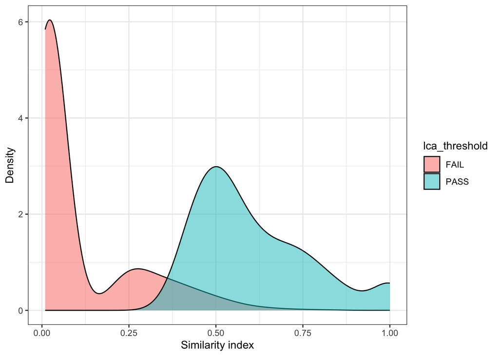

```r
si_df <- si_df |>
  dplyr::mutate(
    lca_threshold = dplyr::if_else(total_descendants < cutoff, "PASS", "FAIL")
  )

ggplot(si_df, aes(x = similarity_index, fill = lca_threshold)) +
  geom_density(bw = 0.05, alpha = 0.5) +
  labs(
    x = "Similarity index",
    y = "Density"
  )
```

This looks as I expected with most of the pairs that pass the total descendants cutoff having a higher similarity index than those that do not pass. There is still some overlap though so perhaps even if a set of terms shares an LCA that passes the threshold, the actual terms being compared may be further apart than we would like.

Now let’s look at the similarity index for various LCA terms. Here each LCA term is its own plot and the vertical lines are the similarity index for each pair of terms that results in that LCA.

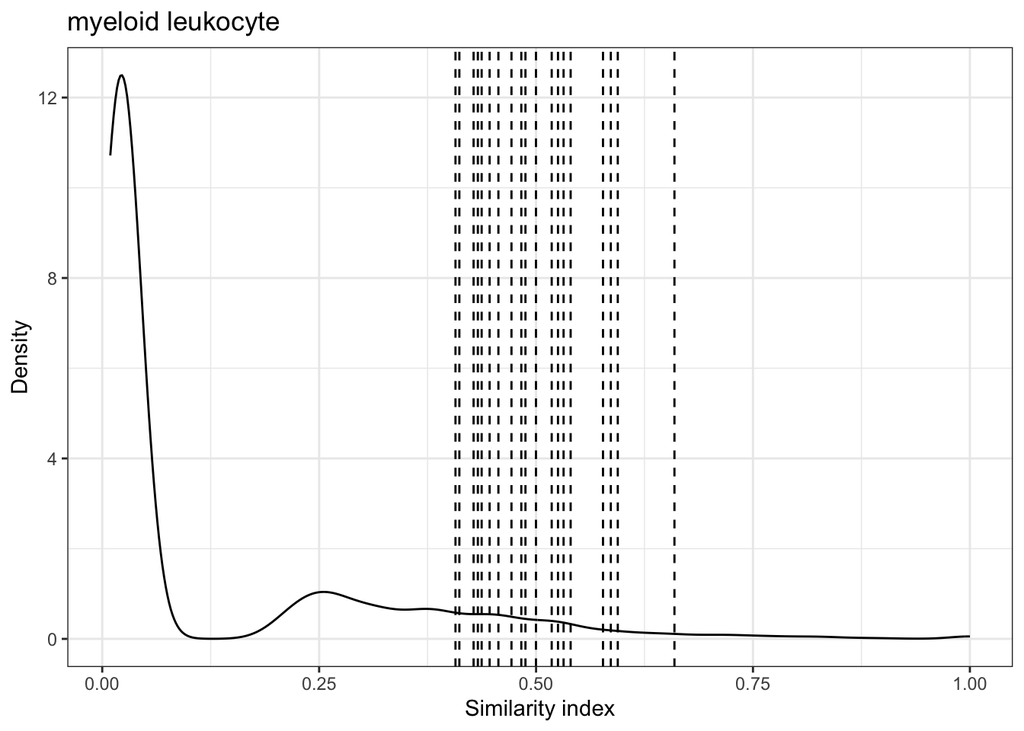

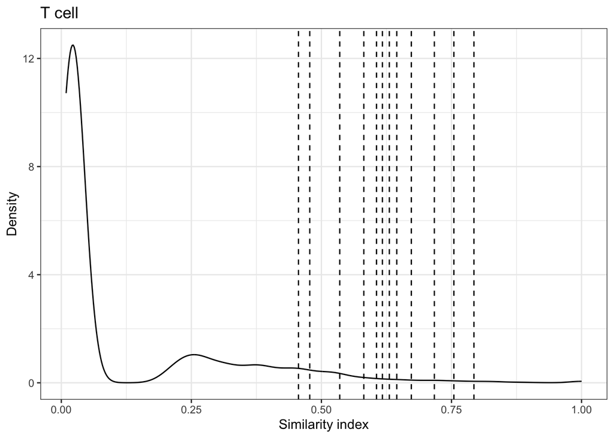

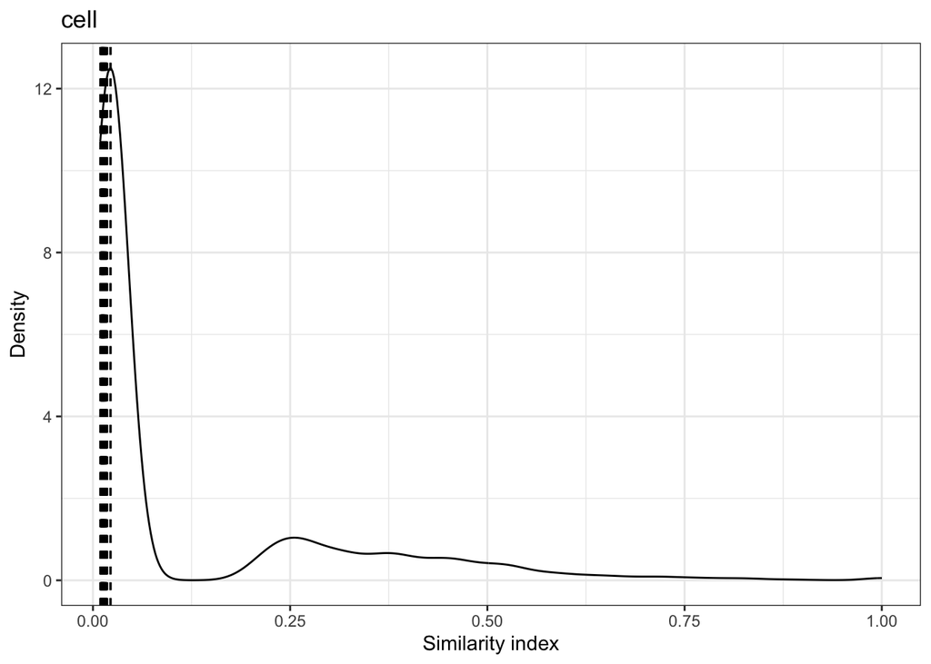

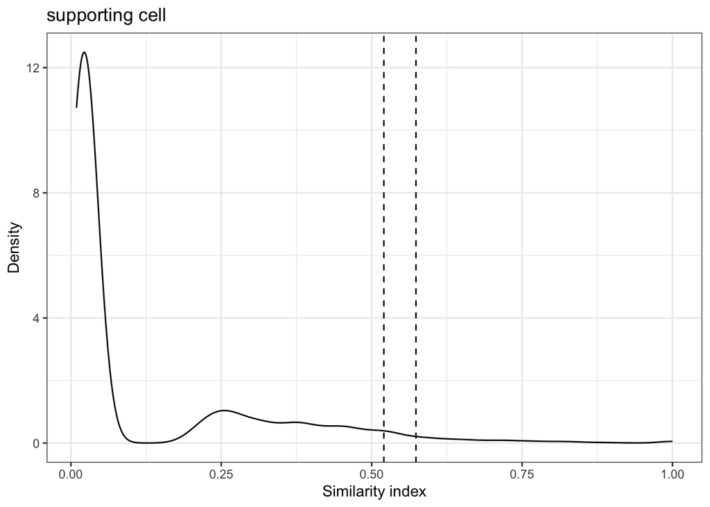

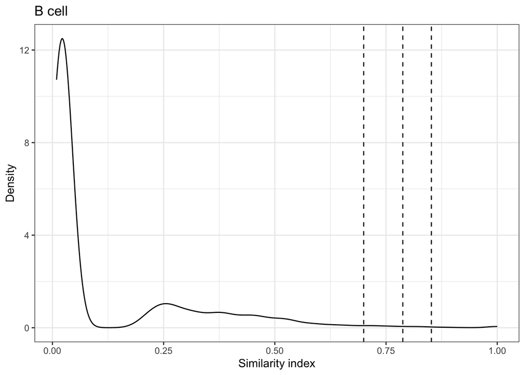

```r
celltypes_to_plot <- c("myeloid leukocyte", "T cell", "cell", "supporting cell", "B cell")

celltypes_to_plot |>
  purrr::map(\(celltype){
    line_df <- si_df |>
      dplyr::filter(cl_annotation == celltype) |>
      dplyr::select(cl_annotation, similarity_index) |>
      unique()

    ggplot(si_df, aes(x = similarity_index)) +
      geom_density() +
      geom_vline(data = line_df,
                 mapping = aes(xintercept = similarity_index),
                 lty = 2) +
      labs(
        x = "Similarity index",
        y = "Density",
        title = celltype
      )

  })
```

It looks like terms that are more granular like T and B cell have higher similarity index values than terms that are less granular which is what we would expect. However, within terms like myeloid leukocyte and even T cell we do see a range of values. We could dig deeper into which pairs are resulting in which similarity index values if we wanted to, but I think that might be a future direction if we feel like the similarity index is something that could be useful.

## Conclusions

Based on these findings, I think it might be best to create a reference that has all possible pairs of labels between PanglaoDB and Blueprint Encode and the resulting consensus label for those pairs. To do this we could come up with a whitelist of LCA terms that we would be comfortable including and all other cell types would be unknowns. I would use the following criteria to come up with my whitelist:

- Pairs should not have more than 1 LCA, with the exception of the matches that have the label hematopoietic precursor cell.
- The LCA should have equal to or less than 170 total descendants.
- We should include the term for `neuron` and

  ```
  epithelial
  cell
  ```

  even though they do not pass the threshold for number of descendants. However, `epithelial cell` should only be included if the Blueprint Encode name is `Epithelial cells` and *not* `Keratinocytes`.
- Terms that are too broad should be removed. This includes:

  ```
  lining
  cell
  ```

  , `blood cell`, `progenitor cell`, `bone cell`, and `supporting cell`

Alternatively, rather than eliminate terms that are too broad we could look at the similarity index for individual matches and decide on a case by case basis if those should be allowed. Although I still think having a term that is too broad, even if it’s a good match, is not super informative.